# Antidepressant Prescribing Report

Usama Masood

March 15, 2025

Introduction

The **NHS Step-Up Challenge** focuses on analyzing antidepressant prescribing trends in England. This report investigates the volume and cost of antidepressant prescriptions across different regions over a four-year period.

# 1 Part One: National & Regional Overview

## 1.1 Visual comparison between Annual Antidepressant prescriptions and Annual prescription Cost

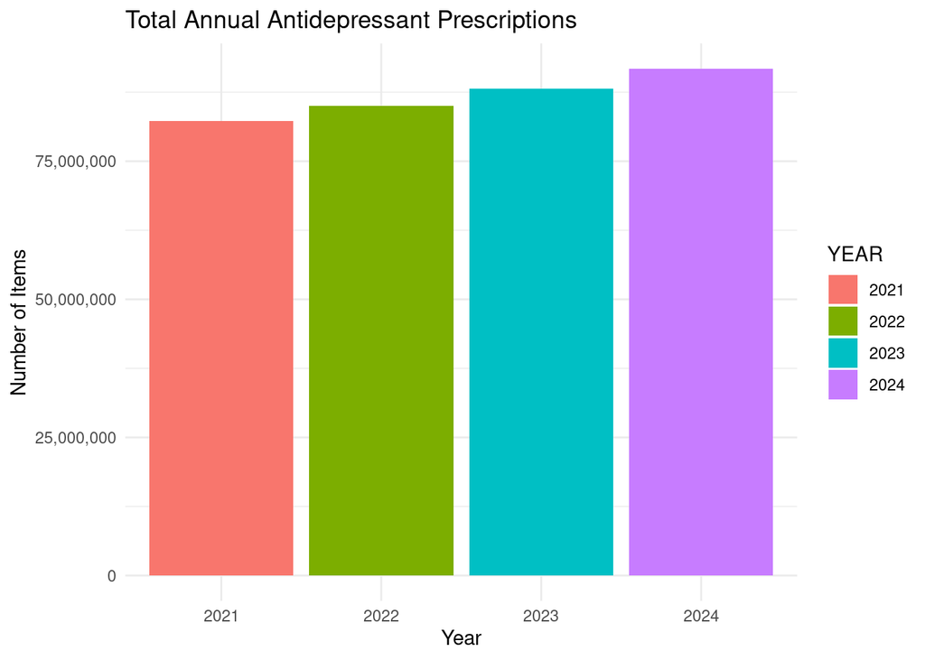

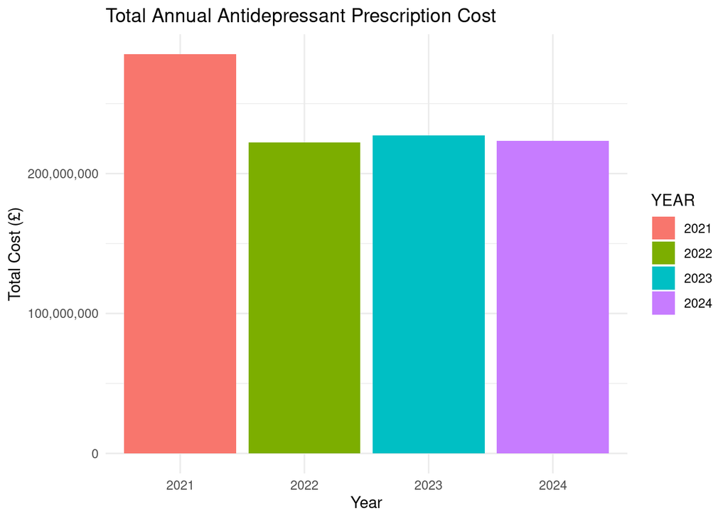

### 1.1.1 Description and Comparison of Trends

- Prescribing Volume Trend (Total Items): The bar chart showing the total antidepressant prescriptions (items) over the years demonstrates a steady increase in prescriptions from 2021 to 2024. This suggests a growing trend in the usage of antidepressants across England during this period.
- Prescription Cost Trend: The bar chart for the total antidepressant prescribing cost shows that the cost total cost for year 2021 is far more than any other year it may be because of COVID-19 after effects. While the cost trend in 2022, 2023 and 2024 is much different but very less than 2021.

### 1.1.2 Comparison

This comparison provides insights into how both prescribing behavior and medication costs are evolving in parallel, with cost decreases first and then remains same outpacing volume increases in some years.

## 1.2 Tabular comparision between total annual antidepressant prescribing per region and annual antidepressant prescribing cost per region.

Total Annual Antidepressant Prescribing per Region (Items)

| REGION | 2021 | 2022 | 2023 | 2024 |
| --- | --- | --- | --- | --- |
| EAST OF ENGLAND | 10088696 | 10386159 | 10715976 | 11082180 |
| LONDON | 7529806 | 7900817 | 8278150 | 8852394 |
| MIDLANDS | 15521842 | 16270811 | 17071488 | 17776322 |
| NORTH EAST AND YORKSHIRE | 16467536 | 16920234 | 17461136 | 18311514 |
| NORTH WEST | 12630435 | 13023335 | 13448199 | 13950677 |
| SOUTH EAST | 11293728 | 11615891 | 11971771 | 12377233 |
| SOUTH WEST | 8754901 | 8939887 | 9160339 | 9386957 |

Total Annual Cost of Antidepressant Prescribing per Region (£)

| REGION | 2021 | 2022 | 2023 | 2024 |
| --- | --- | --- | --- | --- |
| EAST OF ENGLAND | 33887748 | 26732981 | 27274464 | 27162002 |
| LONDON | 27626450 | 21718574 | 22308597 | 22428439 |
| MIDLANDS | 54025265 | 42299049 | 44067727 | 43730514 |
| NORTH EAST AND YORKSHIRE | 49257077 | 37685770 | 38568941 | 37507208 |
| NORTH WEST | 42451998 | 31943711 | 32446429 | 31768651 |
| SOUTH EAST | 47010678 | 37483856 | 37923369 | 37072188 |
| SOUTH WEST | 31068372 | 24354690 | 24795634 | 23856646 |

### 1.2.1 Description and Comparison of Regional Changes Between 2021 and 2024

- Prescribing Volume (Items): From the first table, we can observe the total annual antidepressant prescriptions (items) per region. All regions show steady growth in prescribing volumes over the years. For example, a region with a significant increase in 2024 compared to 2021 could indicate a rise in antidepressant usage, possibly linked to mental health trends or changes in healthcare practices in that region.
- Prescribing Cost: The second table shows the annual antidepressant prescribing cost per region. It has a different trend as compared to above table. The cost for 2021 is much more higher than any other year (May be because of the COVID-19), but remains almost the same for rest of the years.

## 1.3 Visual compariosn between 10 most prescribed antidepressants across the four years and antidepressants with the greatest total prescribing cost across the entire four year period

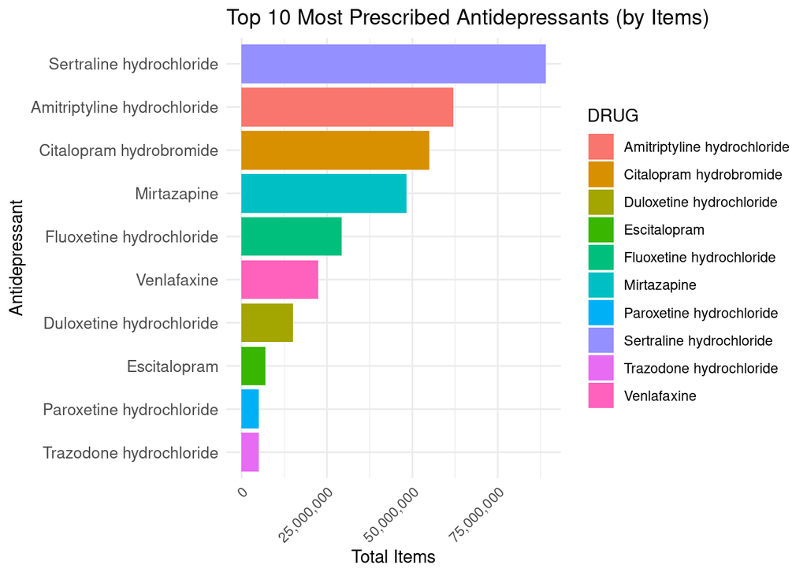

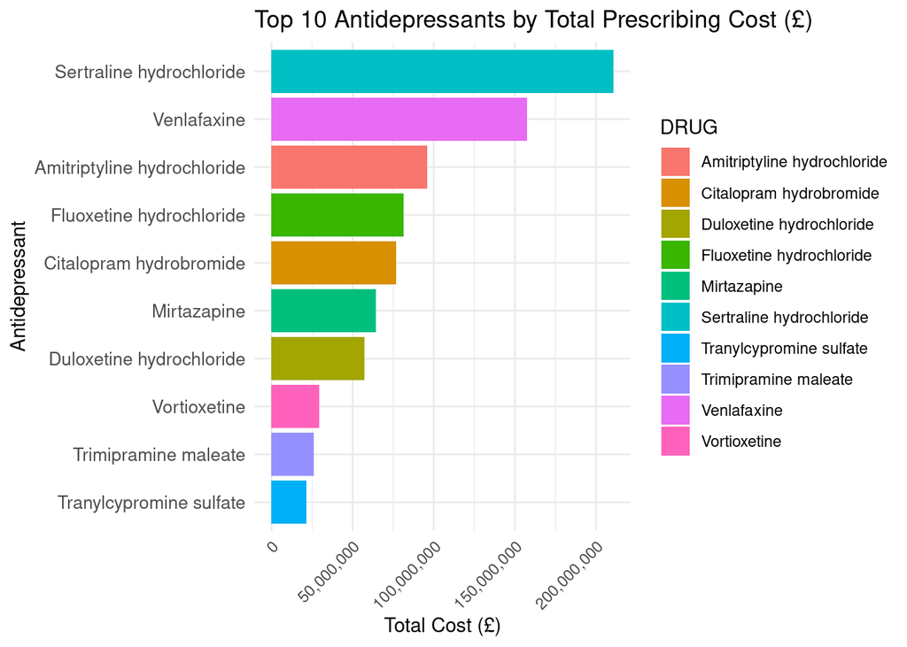

### 1.3.1 Description and Comparison of the Bar Charts

- Most Prescribed Antidepressants (by Items): The first chart shows the 10 most prescribed antidepressants over the four-year period in terms of volume (items). These medications are likely to be more commonly prescribed for treating depression and related conditions across the population. The chart reflects the relative volume of prescriptions for each drug, and we expect to see medications that are well-established and widely used.
- Most Expensive Antidepressants (by Cost): The second chart highlights the 10 antidepressants with the greatest total prescribing cost across the entire four-year period. While the drugs listed here might overlap with the most prescribed ones, we may also see differences. For example, a medication that is prescribed less frequently but has a high cost per unit could appear on this list, resulting in a higher total cost despite a lower volume.

# 2 Part Two: Longitudinal Analysis of Antidepressant Prescribing

In this section, we will explore the longitudinal (monthly) trends for antidepressant items and their associated costs. We will then identify the antidepressant drugs that are driving these trends and provide a high-level summary of our findings.

## 2.1 Longitudinal (Monthly) Trend for All Antidepressant Items

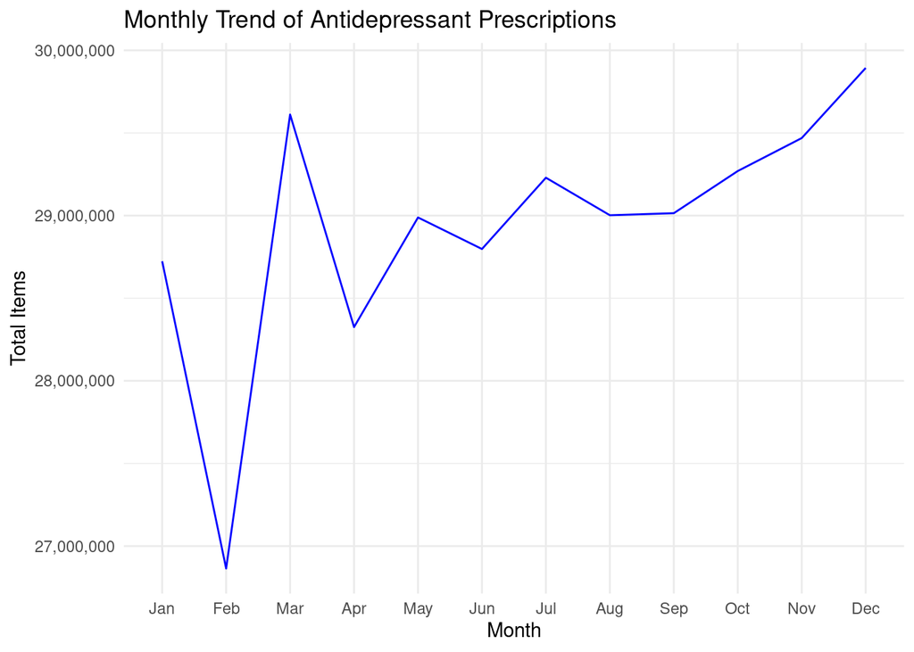

## 2.2 Longitudinal (Monthly) Trend for Antidepressant Prescribing Costs

Next, we will analyze the trend in the total cost of antidepressant prescribing over time. This helps us understand how costs are evolving over the same period.

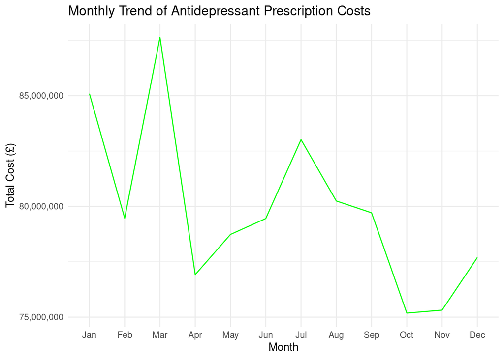

## 2.3 Exploring the Drugs Driving Monthly Item and Cost Trends

To identify which antidepressant drugs are driving the trends in monthly prescribing items and costs, we will focus on drugs that have a significant impact on these metrics.

- Most Prescribed Drugs by Item Count (Monthly)

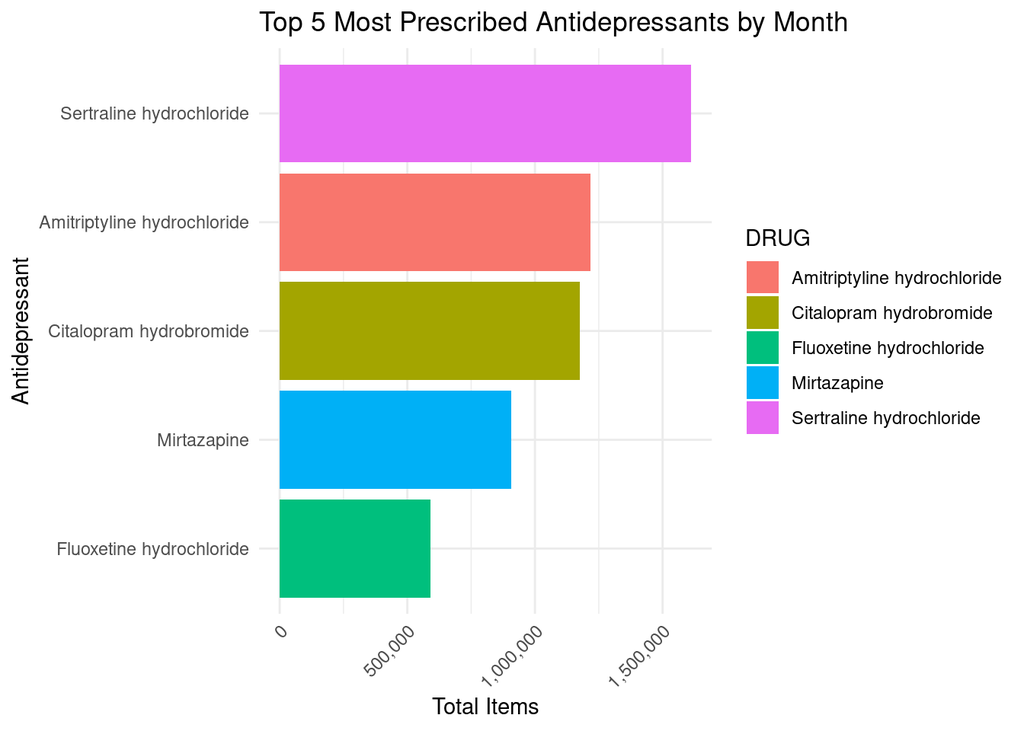

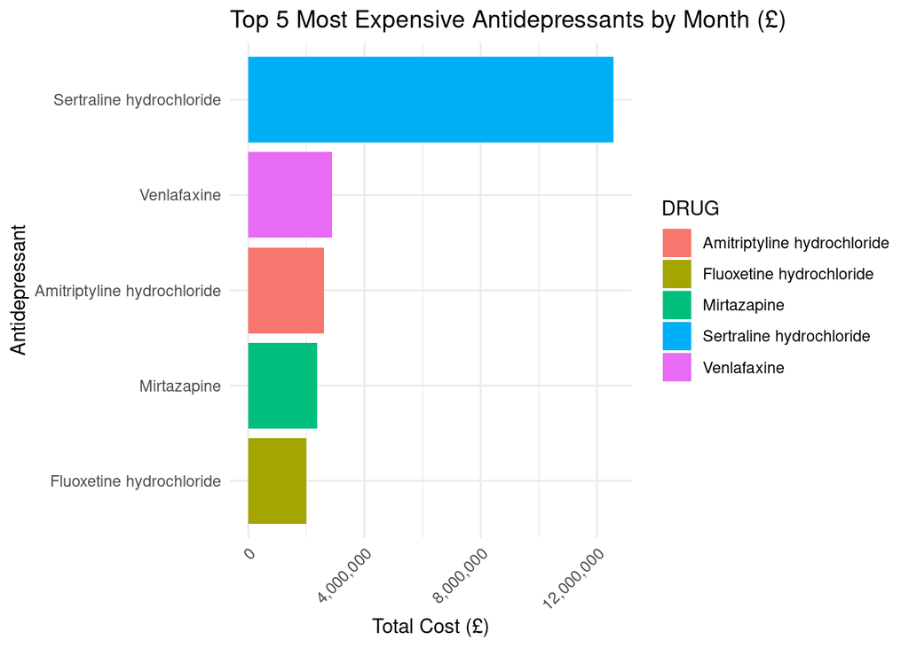

## 2.4 High-Level Summary of Findings

### 2.4.1 Volume Trends:

The monthly trend chart for antidepressant prescriptions highlights the fluctuations in the volume of prescriptions over time. We may observe certain months with higher prescriptions due to factors such as seasonality or changes in healthcare guidelines. It is crucial to note that large spikes or drops in prescriptions may coincide with specific healthcare events or public health campaigns.

### 2.4.2 Cost Trends:

Similarly, the trend for total prescribing costs reveals how the overall cost burden of antidepressants is evolving. Costs may follow a different trend than volume due to the introduction of more expensive drugs or changes in the prices of commonly prescribed medications.

### 2.4.3 Key Drivers:

Through the monthly analysis of the most prescribed and most expensive drugs, we can identify specific medications that are significantly influencing these trends. For example, we may see that a few high-cost medications dominate the total prescribing cost, even though their volume is lower compared to other, more widely prescribed drugs.

### 2.4.4 Implications:

Understanding these trends and the specific drugs driving them can help policymakers, healthcare providers, and researchers identify opportunities for cost reduction, optimize prescribing practices, and provide targeted interventions for patients. Moreover, recognizing patterns in cost and volume can inform future health policy decisions related to antidepressant prescribing.

# 3 Part Two Extension (Antidepressant Case studies)

## 3.1 Identify Significant Antidepressants

Start by summarizing the total volume and total cost of each antidepressant to find out which ones are most prominent.

Top 10 Prescribed Antidepressants

Based on Total Items and Total Cost

| Drug Name | Total Prescriptions | Total Cost (£) |
| --- | --- | --- |
| Sertraline hydrochloride | 89,057,678.00 | £210,706,030.28 |
| Amitriptyline hydrochloride | 61,922,947.00 | £95,811,771.68 |
| Citalopram hydrobromide | 55,026,909.00 | £76,981,743.27 |
| Mirtazapine | 48,345,537.00 | £64,401,794.96 |
| Fluoxetine hydrochloride | 29,226,741.00 | £81,496,305.34 |
| Venlafaxine | 22,352,531.00 | £157,560,670.62 |
| Duloxetine hydrochloride | 14,990,860.00 | £57,396,717.31 |
| Escitalopram | 6,879,472.00 | £13,536,698.33 |
| Paroxetine hydrochloride | 5,088,283.00 | £14,454,752.86 |
| Trazodone hydrochloride | 5,041,912.00 | £18,418,818.45 |

## 3.2 Percentage of Total Volume or Cost from a Drug

Once you’ve identified a prominent drug, you can calculate its percentage contribution to the total volume and cost.

Top 10 Antidepressants by Volume & Cost Percentage

Percentage of Total Prescriptions and Cost

| Drug Name | Total Prescriptions | Total Cost (£) | Volume (%) | Cost (%) |
| --- | --- | --- | --- | --- |
| Sertraline hydrochloride | 89,057,678.00 | £210,706,030.28 | 25.65% | 21.98% |
| Amitriptyline hydrochloride | 61,922,947.00 | £95,811,771.68 | 17.84% | 10.00% |
| Citalopram hydrobromide | 55,026,909.00 | £76,981,743.27 | 15.85% | 8.03% |
| Mirtazapine | 48,345,537.00 | £64,401,794.96 | 13.92% | 6.72% |
| Fluoxetine hydrochloride | 29,226,741.00 | £81,496,305.34 | 8.42% | 8.50% |
| Venlafaxine | 22,352,531.00 | £157,560,670.62 | 6.44% | 16.44% |
| Duloxetine hydrochloride | 14,990,860.00 | £57,396,717.31 | 4.32% | 5.99% |
| Escitalopram | 6,879,472.00 | £13,536,698.33 | 1.98% | 1.41% |
| Paroxetine hydrochloride | 5,088,283.00 | £14,454,752.86 | 1.47% | 1.51% |
| Trazodone hydrochloride | 5,041,912.00 | £18,418,818.45 | 1.45% | 1.92% |

## 3.3 Mean Cost per Item for a Drug

Next, calculate the mean cost per item for each antidepressant and compare them.

Top 10 Antidepressants by Mean Cost per Item

Mean Cost Calculated as Total Cost / Total Items

| Drug Name | Mean Cost per Item (£) |
| --- | --- |
| Tranylcypromine sulfate | £1,341.33 |
| Nefazodone hydrochloride | £582.93 |
| Isocarboxazid | £433.13 |
| Trimipramine maleate | £367.72 |
| Phenelzine sulfate | £292.59 |
| Doxepin | £200.12 |
| Amoxapine | £183.68 |
| Tryptophan | £126.00 |
| Mianserin hydrochloride | £64.67 |
| Oxitriptan | £49.79 |

## 3.4 Distribution of Mean Cost Per Item

You can visualize the distribution of mean cost per item for a selected drug.

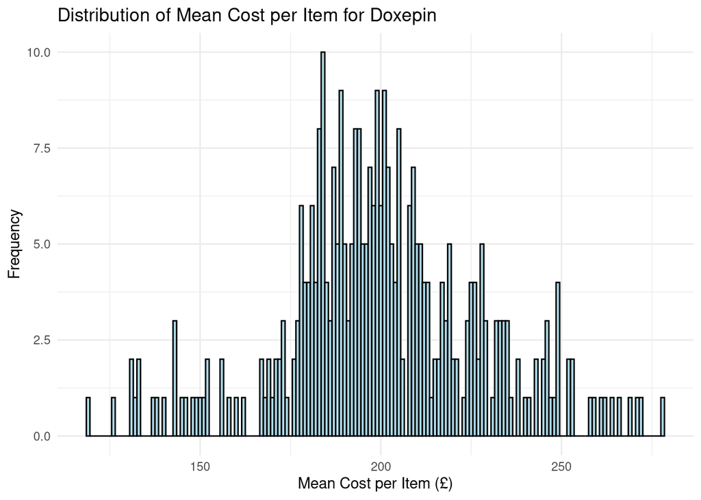

## 3.5 Trend Analysis Over Time for Significant Drug

You can also look at the trend for the selected drug over time.

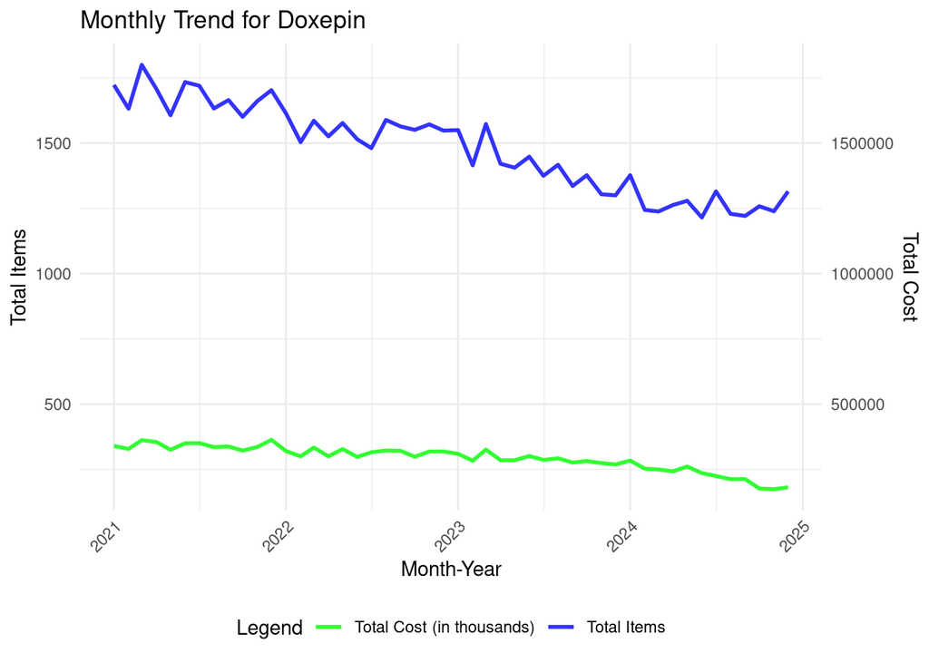

# 4 Conclusion

This report analyzed antidepressant prescribing trends in England using NHS data. The findings highlight significant regional differences, cost variations, and increasing prescription volumes. Further investigation could explore socioeconomic factors influencing these trends.